# Principal Architectures

### Lecture Date: 2025-02-19

```python
import numpy as np
import torch
import torchvision
import torchmetrics
import lightning.pytorch as pl
from torchinfo import summary
from torchview import draw_graph
import matplotlib.pyplot as plt
import pandas as pd
```

- **Numpy:** (`numpy`) for manipulating multidimensional arrays a.k.a. tensors
- **Pytorch:** (`torch`) for building/training deep learning models
- **TorchVision** (`torchvision`) for working with image data sets
- **TorchMetrics** (`torchmetrics`) for loss functions and other statistics
- **Lightning:** (`lightning.pytorch`) for building/training deep learning models quickly and easily
- **TorchInfo:** (`torchinfo`) for printing useful model details
- **TorchView:** (`torchview`) for visualizing deep learning models
- **Matplotlib:** (`matplotlib.pylot`) for visualizing the results of our simulations
- **Pandas:** (`pandas`) for loading tables with mixed data types

```python
# Do we currently have a GPU?
print("GPU available:", torch.cuda.is_available())
```

```
GPU available: True
```

The data set we will be exploring for this lab is the CIFAR10 data set which is loadable using the `torchvision` module since it is a relatively small image processing data set that's both in color and more difficult than the commonly-used MNIST data set. Models comparing MNIST are often only fractions of a percent different in performance when trained properly, and this makes it difficult to spot how architecture might influence results.

Instead, we will load up and prepare CIFAR which has 50,000 images for training/validation and 10,000 images for testing using 10 categories: 0) airplane, 1) automobile, 2) bird, 3) cat, 4) deer, 5) dog, 6) frog, 7) horse, 8) ship, and 9) truck.

Let's load the data and take a quick look at an example:

```python
# Load the data set and scale to [-1,+1]
training_dataset = torchvision.datasets.CIFAR10(root='~/datasets',download=True,train=True)
testing_dataset = torchvision.datasets.CIFAR10(root='~/datasets',download=True,train=False)
x_train = (torch.Tensor(training_dataset.data) / 127.5) - 1.0
y_train = torch.Tensor(training_dataset.targets).to(torch.long)
x_test = (torch.Tensor(testing_dataset.data) / 127.5) - 1.0
y_test = torch.Tensor(testing_dataset.targets).to(torch.long)

# You can set a seed value here if you
# want to control the shuffling process...
rng = np.random.default_rng()
permutation = rng.permutation(x_train.shape[0])
split_point = int(x_train.shape[0] * 0.8) # 80%/20% split

# Split into validation/training - keep test
# set aside for later...
x_val = x_train[permutation][split_point:]
y_val = y_train[permutation][split_point:]
x_train = x_train[permutation][:split_point]
y_train = y_train[permutation][:split_point]

print(x_train.shape)
print(x_val.shape)
print(x_test.shape)
```

```
Files already downloaded and verified
Files already downloaded and verified
torch.Size([40000, 32, 32, 3])
torch.Size([10000, 32, 32, 3])
torch.Size([10000, 32, 32, 3])
```

```python
x_train.shape
```

```
torch.Size([40000, 32, 32, 3])
```

```python
x_train.shape[1:].numel()
```

```
3072
```

```python
y_train.shape
```

```
torch.Size([40000])
```

```python
np.unique(y_train)
```

```
array([0, 1, 2, 3, 4, 5, 6, 7, 8, 9])
```

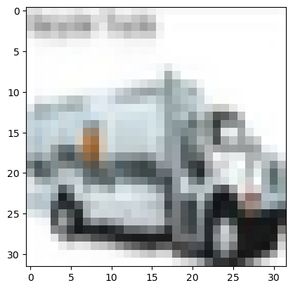

```python
plt.imshow((x_train[0].detach().numpy() + 1.0)/2.0)
plt.show()
```

```python
y_train[0]
```

```
tensor(9)
```

You can also see that these images are 32x32 pixels, and that they are 8-bit color (red, green, blue - 3 channels).

For our experiments, we will be flattening these images and exploring the idea of using single-layer networks, wide networks, deep networks, and residual connections to see how they compare to one-another.

### Prepare DataModule

Even if the above code lets us explore the data set a bit, we should wrap it in a DataModule to make sure the preparation process is stored in the same code/class as the data itself.

```python
class CIFAR10DataModule(pl.LightningDataModule):
    def __init__(self,
                 batch_size = 128,
                 val_split = 0.2,
                 num_workers = 4,
                 location = "~/datasets",
                 **kwargs):
        super().__init__(**kwargs)
        self.batch_size = batch_size
        self.val_split = val_split
        self.num_workers = num_workers
        self.location = location
        self.input_shape = None
        self.output_shape = None
        self.data_train = None
        self.data_val = None
        self.data_test = None

    def setup(self, stage: str):
        if (stage == 'fit' or \
            stage == 'validate') and \
            not(self.data_train and self.data_val):
            training_dataset = torchvision.datasets.CIFAR10(root=self.location,download=True, train=True)
            x_train = training_dataset.data
            x_train = (x_train / 127.5) - 1.0
            y_train = np.array(training_dataset.targets)
            self.input_shape = x_train.shape[1:]
            self.output_shape = (len(np.unique(y_train)),)
            rng = np.random.default_rng()
            permutation = rng.permutation(x_train.shape[0])
            split_point = int(x_train.shape[0]*(1.0-self.val_split))
            self.data_train = list(zip(torch.Tensor(x_train[permutation[:split_point]]).to(torch.float32),
                                       torch.Tensor(y_train[permutation[:split_point]]).to(torch.long)))
            self.data_val = list(zip(torch.Tensor(x_train[permutation[split_point:]]).to(torch.float32),
                                     torch.Tensor(y_train[permutation[split_point:]]).to(torch.long)))
        if (stage == 'test' or \
            stage == 'predict') and \
            not self.data_test:
            testing_dataset = torchvision.datasets.CIFAR10(root=self.location,download=True, train=False)
            x_test = testing_dataset.data
            x_test = (x_test / 127.5) - 1.0
            y_test = np.array(testing_dataset.targets)
            self.input_shape = x_test.shape[1:]
            self.output_shape = (len(np.unique(y_test)),)
            self.data_test = list(zip(torch.Tensor(x_test).to(torch.float32),
                                      torch.Tensor(y_test).to(torch.long)))

    def train_dataloader(self):
        return torch.utils.data.DataLoader(self.data_train,
                                           batch_size=self.batch_size,
                                           num_workers=self.num_workers,
                                           shuffle=True)

    def val_dataloader(self):
        return torch.utils.data.DataLoader(self.data_val,
                                           batch_size=self.batch_size,
                                           num_workers=self.num_workers,
                                           shuffle=False)

    def test_dataloader(self):
        return torch.utils.data.DataLoader(self.data_test,
                                           batch_size=self.batch_size,
                                           num_workers=self.num_workers,
                                           shuffle=False)

    def predict_dataloader(self):
        return torch.utils.data.DataLoader(self.data_test,
                                           batch_size=self.batch_size,
                                           num_workers=self.num_workers,
                                           shuffle=False)
```

Here we actually instantiate the CIFAR10 DataModule needed for training/validation/testing...

```python
data_module = CIFAR10DataModule()
data_module.setup('validate')
```

```
Files already downloaded and verified
```

### Single-layer with Multi-class Targets

Let's start with the control model for our experiments, the single-layer network:

```python
a_batch = next(iter(data_module.train_dataloader()))
x_train = a_batch[0]
y_train = a_batch[1]
```

```python
x_train.shape[1:]
```

```
torch.Size([32, 32, 3])
```

```python
# Input size
np.prod(x_train.shape[1:])
```

```
3072
```

```python
data_module.input_shape
```

```
(32, 32, 3)
```

**Important:** We have a large batch size being used here, so this ends up *typically* getting all 10 classes included in this initial code - but be careful because it might not **always** do so.

```python
# Targets
y_train.unique()
```

```
tensor([0, 1, 2, 3, 4, 5, 6, 7, 8, 9])
```

```python
# Output size
len(y_train.unique())
```

```
10
```

```python
data_module.output_shape[-1]
```

```
10
```

Carefully note the number of units in the input/output layers and the choice of activation function...

```python
# Define Trainable Module (boilerplate)
class MulticlassPLModule(pl.LightningModule):
    def __init__(self, n_classes, **kwargs):
        # This is the contructor, where we typically make
        # layer objects using provided arguments.
        super().__init__(**kwargs) # Call the super class constructor

        # This creates an accuracy function
        self.model_acc = torchmetrics.classification.Accuracy(task='multiclass',
                                                              num_classes=n_classes)
        # This creates a loss function
        self.model_loss = torch.nn.CrossEntropyLoss()

    def configure_optimizers(self):
        optimizer = torch.optim.Adam(self.parameters(), lr=0.001)
        return optimizer

    def predict_step(self, predict_batch, batch_idx):
        x, y_true = train_batch
        y_pred = self.predict(x)
        return y_pred, y_true

    def training_step(self, train_batch, batch_idx):
        x, y_true = train_batch
        y_pred = self(x)
        acc = self.model_acc(y_pred,y_true)
        loss = self.model_loss(y_pred,y_true)
        self.log('train_acc', acc, on_step=False, on_epoch=True)
        self.log('train_loss', loss, on_step=False, on_epoch=True)
        return loss

    def validation_step(self, val_batch, batch_idx):
        x, y_true = val_batch
        y_pred = self(x)
        acc = self.model_acc(y_pred,y_true)
        loss = self.model_loss(y_pred,y_true)
        self.log('val_acc', acc, on_step=False, on_epoch=True)
        self.log('val_loss', loss, on_step=False, on_epoch=True)
        return loss

    def test_step(self, test_batch, batch_idx):
        x, y_true = test_batch
        y_pred = self(x)
        acc = self.model_acc(y_pred,y_true)
        loss = self.model_loss(y_pred,y_true)
        self.log('test_acc', acc, on_step=False, on_epoch=True)
        self.log('test_loss', loss, on_step=False, on_epoch=True)
        return loss
```

```python
# Define model
class SingleLayerNetwork(MulticlassPLModule):
    def __init__(self,
                 input_shape,
                 output_shape,
                 **kwargs):
        super().__init__(n_classes=output_shape[-1],
                         **kwargs)
        self.flatten_layer = torch.nn.Flatten()
        self.output_layer = torch.nn.Linear(np.prod(input_shape),
                                            output_shape[-1])
        self.activation = torch.nn.Softmax(dim=-1)

    def forward(self, x):
        y = x
        y = self.flatten_layer(y)
        y = self.output_layer(y)
        return y

    # Note - not a PL function
    def predict(self, x):
        y = x
        y = self.forward(y)
        y = self.activation(y)
        return y
```

```python
model = SingleLayerNetwork(data_module.input_shape,
                           data_module.output_shape)
```

```python
summary(model, input_size=(1,)+data_module.input_shape)
```

```
==========================================================================================
Layer (type:depth-idx)                   Output Shape              Param #
==========================================================================================
SingleLayerNetwork                       [1, 10]                   --
├─Flatten: 1-1                           [1, 3072]                 --
├─Linear: 1-2                            [1, 10]                   30,730
==========================================================================================
Total params: 30,730
Trainable params: 30,730
Non-trainable params: 0
Total mult-adds (Units.MEGABYTES): 0.03
==========================================================================================
Input size (MB): 0.01
Forward/backward pass size (MB): 0.00
Params size (MB): 0.12
Estimated Total Size (MB): 0.14
==========================================================================================
```

```python
model_graph = draw_graph(model, input_size=(1,)+data_module.input_shape, depth=1)
model_graph.visual_graph
```

[figure not shown]

```python
predictions = model.predict(x_train[:5].to(model.device)).cpu().detach().numpy()
predictions
```

```
array([[0.07408275, 0.13512687, 0.06361866, 0.07818349, 0.10342111,
        0.13739273, 0.11423202, 0.12872113, 0.07765831, 0.0875629 ],
       [0.21581784, 0.04536344, 0.10711548, 0.09783664, 0.05897164,
        0.04859095, 0.11056374, 0.09744713, 0.12721682, 0.09107634],
       [0.09353206, 0.12386911, 0.10520244, 0.06959342, 0.07449555,
        0.07750444, 0.10323343, 0.11494223, 0.10462406, 0.13300325],
       [0.10058598, 0.07083383, 0.13886835, 0.07696628, 0.09407603,
        0.10325591, 0.0996952 , 0.10048983, 0.10235538, 0.11287322],
       [0.11092078, 0.09660576, 0.10518964, 0.11326703, 0.10628363,
        0.09112215, 0.10962715, 0.10680666, 0.07393508, 0.08624211]],
      dtype=float32)
```

```python
predictions.shape
```

```
(5, 10)
```

```python
predictions.argmax(-1)
```

```
array([5, 0, 9, 2, 3])
```

```python
y_train[:5]
```

```
tensor([7, 4, 0, 8, 7])
```

```python
model.model_loss(model(x_train[:5].to(model.device)),
                 y_train[:5].to(model.device)).cpu().detach().numpy()
```

```
array(2.3532593, dtype=float32)
```

```python
model.model_acc(model(x_train[:5].to(model.device)),
                y_train[:5].to(model.device)).cpu().detach().numpy()
```

```
array(0., dtype=float32)
```

We are **not using a softmax activation function (on the output layer)** because we have the crossentropy loss function which anticpates the outputs are not probabilities but instead represent **weighted selections (logits)**. This is just a slightly more efficient computation than using the softmax activation function: you can optionally use the softmax activation function by using the `predict()` method instead of the `forward()` function (also called using the `()` operator).

```python
logger = pl.loggers.CSVLogger("logs",
                              name="Principal-Architectures",
                              version="demo-0")
```

```python
trainer = pl.Trainer(logger=logger,
                     max_epochs=50,
                     enable_progress_bar=True,
                     log_every_n_steps=0,
                     callbacks=[pl.callbacks.TQDMProgressBar(refresh_rate=20)])
```

```
GPU available: True (cuda), used: True
TPU available: False, using: 0 TPU cores
HPU available: False, using: 0 HPUs
```

```python
trainer.validate(model, data_module)
```

```
/opt/conda/lib/python3.12/site-packages/lightning/fabric/loggers/csv_logs.py:268: Experiment logs directory logs/Principal-Architectures/demo-0 exists and is not empty. Previous log files in this directory will be deleted when the new ones are saved!
LOCAL_RANK: 0 - CUDA_VISIBLE_DEVICES: [0]
SLURM auto-requeueing enabled. Setting signal handlers.
```

```
Validation: |          | 0/? [00:00<?, ?it/s]
```

```
┏━━━━━━━━━━━━━━━━━━━━━━━━━━━┳━━━━━━━━━━━━━━━━━━━━━━━━━━━┓
┃      Validate metric      ┃       DataLoader 0        ┃
┡━━━━━━━━━━━━━━━━━━━━━━━━━━━╇━━━━━━━━━━━━━━━━━━━━━━━━━━━┩
│          val_acc          │    0.12690000236034393    │
│         val_loss          │    2.2769548892974854     │
└───────────────────────────┴───────────────────────────┘
```

```
[{'val_acc': 0.12690000236034393, 'val_loss': 2.2769548892974854}]
```

```python
trainer.fit(model, data_module)
```

```
/opt/conda/lib/python3.12/site-packages/lightning/pytorch/callbacks/model_checkpoint.py:654: Checkpoint directory logs/Principal-Architectures/demo-0/checkpoints exists and is not empty.
LOCAL_RANK: 0 - CUDA_VISIBLE_DEVICES: [0]

  | Name          | Type               | Params | Mode
-------------------------------------------------------------
0 | model_acc     | MulticlassAccuracy | 0      | train
1 | model_loss    | CrossEntropyLoss   | 0      | train
2 | flatten_layer | Flatten            | 0      | train
3 | output_layer  | Linear             | 30.7 K | train
4 | activation    | Softmax            | 0      | train
-------------------------------------------------------------
30.7 K    Trainable params
0         Non-trainable params
30.7 K    Total params
0.123     Total estimated model params size (MB)
5         Modules in train mode
0         Modules in eval mode
SLURM auto-requeueing enabled. Setting signal handlers.
```

```
Sanity Checking: |          | 0/? [00:00<?, ?it/s]
```

```
Training: |          | 0/? [00:00<?, ?it/s]
```

[output not shown]

[output not shown]

[output not shown]

[output not shown]

[output not shown]

[output not shown]

[output not shown]

[output not shown]

[output not shown]

[output not shown]

[output not shown]

[output not shown]

[output not shown]

[output not shown]

[output not shown]

[output not shown]

[output not shown]

[output not shown]

[output not shown]

[output not shown]

[output not shown]

[output not shown]

[output not shown]

[output not shown]

[output not shown]

[output not shown]

[output not shown]

[output not shown]

[output not shown]

[output not shown]

[output not shown]

[output not shown]

[output not shown]

[output not shown]

[output not shown]

[output not shown]

[output not shown]

[output not shown]

[output not shown]

[output not shown]

[output not shown]

[output not shown]

[output not shown]

[output not shown]

[output not shown]

[output not shown]

[output not shown]

[output not shown]

[output not shown]

[output not shown]

```
`Trainer.fit` stopped: `max_epochs=50` reached.
```

```python
trainer.validate(model, data_module)
```

```
LOCAL_RANK: 0 - CUDA_VISIBLE_DEVICES: [0]
SLURM auto-requeueing enabled. Setting signal handlers.
```

```
Validation: |          | 0/? [00:00<?, ?it/s]
```

```
┏━━━━━━━━━━━━━━━━━━━━━━━━━━━┳━━━━━━━━━━━━━━━━━━━━━━━━━━━┓
┃      Validate metric      ┃       DataLoader 0        ┃
┡━━━━━━━━━━━━━━━━━━━━━━━━━━━╇━━━━━━━━━━━━━━━━━━━━━━━━━━━┩
│          val_acc          │    0.38119998574256897    │
│         val_loss          │    1.8400009870529175     │
└───────────────────────────┴───────────────────────────┘
```

```
[{'val_acc': 0.38119998574256897, 'val_loss': 1.8400009870529175}]
```

```python
results = pd.read_csv(logger.log_dir+"/metrics.csv")
results
```

|  | epoch | step | train_acc | train_loss | val_acc | val_loss |
| --- | --- | --- | --- | --- | --- | --- |
| 0 | 0 | 0 | NaN | NaN | 0.1269 | 2.276955 |
| 1 | 0 | 312 | NaN | NaN | 0.3856 | 1.790521 |
| 2 | 0 | 312 | 0.360975 | 1.850031 | NaN | NaN |
| 3 | 1 | 625 | NaN | NaN | 0.3924 | 1.778415 |
| 4 | 1 | 625 | 0.393125 | 1.772737 | NaN | NaN |
| ... | ... | ... | ... | ... | ... | ... |
| 97 | 48 | 15336 | NaN | NaN | 0.3767 | 1.808893 |
| 98 | 48 | 15336 | 0.443350 | 1.626942 | NaN | NaN |
| 99 | 49 | 15649 | NaN | NaN | 0.3812 | 1.840001 |
| 100 | 49 | 15649 | 0.447175 | 1.618789 | NaN | NaN |
| 101 | 50 | 15650 | NaN | NaN | 0.3812 | 1.840001 |

102 rows × 6 columns

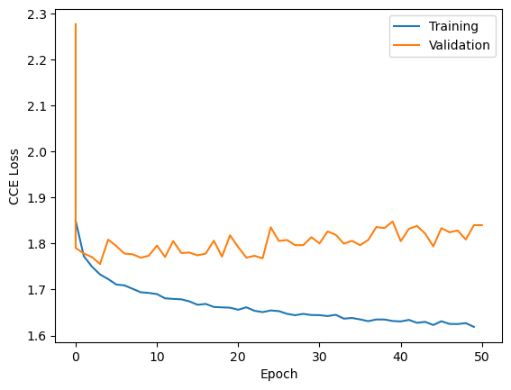

```python
plt.plot(results["epoch"][np.logical_not(np.isnan(results["train_loss"]))],
         results["train_loss"][np.logical_not(np.isnan(results["train_loss"]))],
         label="Training")
plt.plot(results["epoch"][np.logical_not(np.isnan(results["val_loss"]))],
         results["val_loss"][np.logical_not(np.isnan(results["val_loss"]))],
         label="Validation")
plt.legend()
plt.ylabel("CCE Loss")
plt.xlabel("Epoch")
plt.show()
```

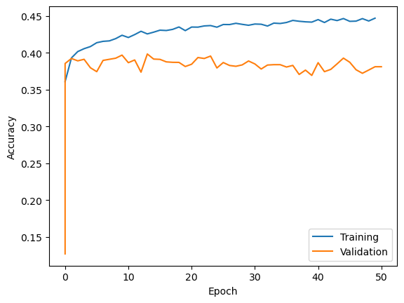

```python
plt.plot(results["epoch"][np.logical_not(np.isnan(results["train_acc"]))],
         results["train_acc"][np.logical_not(np.isnan(results["train_acc"]))],
         label="Training")
plt.plot(results["epoch"][np.logical_not(np.isnan(results["val_acc"]))],
         results["val_acc"][np.logical_not(np.isnan(results["val_acc"]))],
         label="Validation")
plt.legend()
plt.ylabel("Accuracy")
plt.xlabel("Epoch")
plt.show()
```

```python
print("Validation accuracy:",*["%.8f"%(x) for x in
                               results['val_acc'][np.logical_not(np.isnan(results["val_acc"]))]])
```

[output not shown]

```python
print("Testing accuracy:", trainer.test(model, data_module)[0]['test_acc'])
```

```
Files already downloaded and verified
```

```
LOCAL_RANK: 0 - CUDA_VISIBLE_DEVICES: [0]
SLURM auto-requeueing enabled. Setting signal handlers.
```

```
Testing: |          | 0/? [00:00<?, ?it/s]
```

```
┏━━━━━━━━━━━━━━━━━━━━━━━━━━━┳━━━━━━━━━━━━━━━━━━━━━━━━━━━┓
┃        Test metric        ┃       DataLoader 0        ┃
┡━━━━━━━━━━━━━━━━━━━━━━━━━━━╇━━━━━━━━━━━━━━━━━━━━━━━━━━━┩
│         test_acc          │    0.37549999356269836    │
│         test_loss         │    1.8474490642547607     │
└───────────────────────────┴───────────────────────────┘
```

```
Testing accuracy: 0.37549999356269836
```

Not very good performance here overall, but we now have a **baseline model** for performing comparisons with wide, deep, and residually connected multi-layer networks...

### Widening...

To make fair comparisons, we have to keep the number of parameters in mind. Having too many extra parameters is an unfair advantage for a model. Of course, the single-layer model below is about as small as we can get with flattened input vectors, so the rest of the architectures will have more parameters by necessity.

```python
# Define model
class WideNetwork(MulticlassPLModule):
    def __init__(self,
                 input_shape,
                 output_shape,
                 hidden_size,
                 **kwargs):
        super().__init__(n_classes=output_shape[-1],
                         **kwargs)
        self.flatten_layer = torch.nn.Flatten()
        self.hidden_layer = torch.nn.Linear(np.prod(input_shape),
                                            hidden_size)
        self.hidden_activation = torch.nn.Tanh()
        self.output_layer = torch.nn.Linear(hidden_size,
                                            output_shape[-1])

    def forward(self, x):
        y = x
        y = self.flatten_layer(y)
        y = self.hidden_activation(self.hidden_layer(y))
        y = self.output_layer(y)
        return y

    def predict(self, x):
        y = x
        y = self.forward(y)
        y = torch.softmax(y,-1)
        return y
```

```python
hidden_dim = 256
model = WideNetwork(data_module.input_shape,
                    data_module.output_shape,
                    hidden_dim)
summary(model, input_size=(1,)+data_module.input_shape)
```

```
==========================================================================================
Layer (type:depth-idx)                   Output Shape              Param #
==========================================================================================
WideNetwork                              [1, 10]                   --
├─Flatten: 1-1                           [1, 3072]                 --
├─Linear: 1-2                            [1, 256]                  786,688
├─Tanh: 1-3                              [1, 256]                  --
├─Linear: 1-4                            [1, 10]                   2,570
==========================================================================================
Total params: 789,258
Trainable params: 789,258
Non-trainable params: 0
Total mult-adds (Units.MEGABYTES): 0.79
==========================================================================================
Input size (MB): 0.01
Forward/backward pass size (MB): 0.00
Params size (MB): 3.16
Estimated Total Size (MB): 3.17
==========================================================================================
```

```python
# Note the depth setting...
model_graph = draw_graph(model, input_size=(1,)+data_module.input_shape, depth=3)
model_graph.visual_graph
```

[figure not shown]

### Deepening...

Deep models alone have no residual connections, but focus on stacking layers to distribute the parameters. Here is an example of a deep network which is close to the same number of parameters above (still too large, and probably deeper than you might want) which illustrates the concept...

```python
# Define model
class DeepNetwork(MulticlassPLModule):
    def __init__(self,
                 input_shape,
                 output_shape,
                 hidden_size,
                 num_hidden_layers,
                 **kwargs):
        super().__init__(n_classes=output_shape[-1],**kwargs)
        self.flatten_layer = torch.nn.Flatten()

        # Initial linear projection
        layers = [torch.nn.Linear(np.prod(input_shape),
                                  hidden_size)]
        for _ in range(num_hidden_layers):
            layers = layers + [torch.nn.Linear(hidden_size,
                                               hidden_size),
                               torch.nn.Tanh()]

        self.hidden_layers = torch.nn.Sequential(*layers)
        self.output_layer = torch.nn.Linear(hidden_size,
                                            output_shape[-1])

    def forward(self, x):
        y = x
        y = self.flatten_layer(y)
        y = self.hidden_layers(y)
        y = self.output_layer(y)
        return y

    def predict(self, x):
        y = x
        y = self.forward(y)
        y = torch.softmax(y,-1)
        return y
```

```python
hidden_dim = 128
num_hidden_layers = 20
model = DeepNetwork(data_module.input_shape,
                    data_module.output_shape,
                    hidden_dim,
                    num_hidden_layers)
summary(model, input_size=(1,)+data_module.input_shape)
```

```
==========================================================================================
Layer (type:depth-idx)                   Output Shape              Param #
==========================================================================================
DeepNetwork                              [1, 10]                   --
├─Flatten: 1-1                           [1, 3072]                 --
├─Sequential: 1-2                        [1, 128]                  --
│    └─Linear: 2-1                       [1, 128]                  393,344
│    └─Linear: 2-2                       [1, 128]                  16,512
│    └─Tanh: 2-3                         [1, 128]                  --
│    └─Linear: 2-4                       [1, 128]                  16,512
│    └─Tanh: 2-5                         [1, 128]                  --
│    └─Linear: 2-6                       [1, 128]                  16,512
│    └─Tanh: 2-7                         [1, 128]                  --
│    └─Linear: 2-8                       [1, 128]                  16,512
│    └─Tanh: 2-9                         [1, 128]                  --
│    └─Linear: 2-10                      [1, 128]                  16,512
│    └─Tanh: 2-11                        [1, 128]                  --
│    └─Linear: 2-12                      [1, 128]                  16,512
│    └─Tanh: 2-13                        [1, 128]                  --
│    └─Linear: 2-14                      [1, 128]                  16,512
│    └─Tanh: 2-15                        [1, 128]                  --
│    └─Linear: 2-16                      [1, 128]                  16,512
│    └─Tanh: 2-17                        [1, 128]                  --
│    └─Linear: 2-18                      [1, 128]                  16,512
│    └─Tanh: 2-19                        [1, 128]                  --
│    └─Linear: 2-20                      [1, 128]                  16,512
│    └─Tanh: 2-21                        [1, 128]                  --
│    └─Linear: 2-22                      [1, 128]                  16,512
│    └─Tanh: 2-23                        [1, 128]                  --
│    └─Linear: 2-24                      [1, 128]                  16,512
│    └─Tanh: 2-25                        [1, 128]                  --
│    └─Linear: 2-26                      [1, 128]                  16,512
│    └─Tanh: 2-27                        [1, 128]                  --
│    └─Linear: 2-28                      [1, 128]                  16,512
│    └─Tanh: 2-29                        [1, 128]                  --
│    └─Linear: 2-30                      [1, 128]                  16,512
│    └─Tanh: 2-31                        [1, 128]                  --
│    └─Linear: 2-32                      [1, 128]                  16,512
│    └─Tanh: 2-33                        [1, 128]                  --
│    └─Linear: 2-34                      [1, 128]                  16,512
│    └─Tanh: 2-35                        [1, 128]                  --
│    └─Linear: 2-36                      [1, 128]                  16,512
│    └─Tanh: 2-37                        [1, 128]                  --
│    └─Linear: 2-38                      [1, 128]                  16,512
│    └─Tanh: 2-39                        [1, 128]                  --
│    └─Linear: 2-40                      [1, 128]                  16,512
│    └─Tanh: 2-41                        [1, 128]                  --
├─Linear: 1-3                            [1, 10]                   1,290
==========================================================================================
Total params: 724,874
Trainable params: 724,874
Non-trainable params: 0
Total mult-adds (Units.MEGABYTES): 0.72
==========================================================================================
Input size (MB): 0.01
Forward/backward pass size (MB): 0.02
Params size (MB): 2.90
Estimated Total Size (MB): 2.93
==========================================================================================
```

```python
# Note the depth setting...
model_graph = draw_graph(model, input_size=(1,)+data_module.input_shape, depth=3)
model_graph.visual_graph
```

[figure not shown]

### Residual Connections

Including residual connections can increase the number of parameters if used naively, but some adjustments to the structure can make this not so problematic...

```python
# Define residual layer
class ResidualLayer(pl.LightningModule):
    def __init__(self,
                 hidden_size,
                 **kwargs):
        super().__init__(**kwargs)
        self.residual = torch.nn.Linear(hidden_size,
                                        hidden_size)
        self.activation = torch.nn.Tanh()

    def forward(self, x):
        y = x
        y = self.activation(self.residual(y))
        y = y + x # Add residual
        return y

class ResidualNetwork(MulticlassPLModule):
    def __init__(self,
                 input_shape,
                 output_shape,
                 hidden_size,
                 num_hidden_layers,
                 **kwargs):
        super().__init__(n_classes=output_shape[-1],
                         **kwargs)
        self.flatten_layer = torch.nn.Flatten()

        # Initial linear projection
        layers = [torch.nn.Linear(np.prod(input_shape),
                                  hidden_size)]
        for _ in range(num_hidden_layers):
            layers = layers + [ResidualLayer(hidden_size)]

        self.hidden_layers = torch.nn.Sequential(*layers)
        self.output_layer = torch.nn.Linear(hidden_size,
                                            output_shape[-1])

    def forward(self, x):
        y = x
        y = self.flatten_layer(y)
        y = self.hidden_layers(y)
        y = self.output_layer(y)
        return y

    def predict(self, x):
        y = x
        y = self.forward(y)
        y = torch.softmax(y,-1)
        return y
```

```python
hidden_dim = 128
num_hidden_layers = 20
model = ResidualNetwork(data_module.input_shape,
                        data_module.output_shape,
                        hidden_dim,
                        num_hidden_layers)
summary(model, input_size=(1,)+data_module.input_shape)
```

```
==========================================================================================
Layer (type:depth-idx)                   Output Shape              Param #
==========================================================================================
ResidualNetwork                          [1, 10]                   --
├─Flatten: 1-1                           [1, 3072]                 --
├─Sequential: 1-2                        [1, 128]                  --
│    └─Linear: 2-1                       [1, 128]                  393,344
│    └─ResidualLayer: 2-2                [1, 128]                  --
│    │    └─Linear: 3-1                  [1, 128]                  16,512
│    │    └─Tanh: 3-2                    [1, 128]                  --
│    └─ResidualLayer: 2-3                [1, 128]                  --
│    │    └─Linear: 3-3                  [1, 128]                  16,512
│    │    └─Tanh: 3-4                    [1, 128]                  --
│    └─ResidualLayer: 2-4                [1, 128]                  --
│    │    └─Linear: 3-5                  [1, 128]                  16,512
│    │    └─Tanh: 3-6                    [1, 128]                  --
│    └─ResidualLayer: 2-5                [1, 128]                  --
│    │    └─Linear: 3-7                  [1, 128]                  16,512
│    │    └─Tanh: 3-8                    [1, 128]                  --
│    └─ResidualLayer: 2-6                [1, 128]                  --
│    │    └─Linear: 3-9                  [1, 128]                  16,512
│    │    └─Tanh: 3-10                   [1, 128]                  --
│    └─ResidualLayer: 2-7                [1, 128]                  --
│    │    └─Linear: 3-11                 [1, 128]                  16,512
│    │    └─Tanh: 3-12                   [1, 128]                  --
│    └─ResidualLayer: 2-8                [1, 128]                  --
│    │    └─Linear: 3-13                 [1, 128]                  16,512
│    │    └─Tanh: 3-14                   [1, 128]                  --
│    └─ResidualLayer: 2-9                [1, 128]                  --
│    │    └─Linear: 3-15                 [1, 128]                  16,512
│    │    └─Tanh: 3-16                   [1, 128]                  --
│    └─ResidualLayer: 2-10               [1, 128]                  --
│    │    └─Linear: 3-17                 [1, 128]                  16,512
│    │    └─Tanh: 3-18                   [1, 128]                  --
│    └─ResidualLayer: 2-11               [1, 128]                  --
│    │    └─Linear: 3-19                 [1, 128]                  16,512
│    │    └─Tanh: 3-20                   [1, 128]                  --
│    └─ResidualLayer: 2-12               [1, 128]                  --
│    │    └─Linear: 3-21                 [1, 128]                  16,512
│    │    └─Tanh: 3-22                   [1, 128]                  --
```

[output cut: 24 more lines]

```
│    └─ResidualLayer: 2-21               [1, 128]                  --
│    │    └─Linear: 3-39                 [1, 128]                  16,512
│    │    └─Tanh: 3-40                   [1, 128]                  --
├─Linear: 1-3                            [1, 10]                   1,290
==========================================================================================
Total params: 724,874
Trainable params: 724,874
Non-trainable params: 0
Total mult-adds (Units.MEGABYTES): 0.72
==========================================================================================
Input size (MB): 0.01
Forward/backward pass size (MB): 0.02
Params size (MB): 2.90
Estimated Total Size (MB): 2.93
==========================================================================================
```

```python
# Note the depth setting...
model_graph = draw_graph(model, input_size=(1,)+data_module.input_shape, depth=3)
model_graph.visual_graph
```

[figure not shown]

## Other Residual Architectures (beyond OL5)

```python
shape = (1,4)
ones = np.ones(shape=shape)
```

```python
# Define model
class NeuralNetwork(pl.LightningModule):
    def __init__(self,
                 **kwargs):
        super().__init__(**kwargs)

    def forward(self, x):
        y = x
        return y

    def predict(self, x):
        y = self.forward(x)
        return y
```

```python
model = NeuralNetwork()
```

```python
summary(model, input_size=shape)
```

```
==========================================================================================
Layer (type:depth-idx)                   Output Shape              Param #
==========================================================================================
NeuralNetwork                            [1, 4]                    --
==========================================================================================
Total params: 0
Trainable params: 0
Non-trainable params: 0
Total mult-adds (Units.MEGABYTES): 0
==========================================================================================
Input size (MB): 0.00
Forward/backward pass size (MB): 0.00
Params size (MB): 0.00
Estimated Total Size (MB): 0.00
==========================================================================================
```

```python
model_graph = draw_graph(model,
                         input_size=shape,
                         depth=1,
                         device=model.device)
model_graph.visual_graph
```

[figure not shown]

# Common Residual Structure

```python
# Define model
class NeuralNetwork(pl.LightningModule):
    def __init__(self,
                 **kwargs):
        super().__init__(**kwargs)

        self.projection = torch.nn.Linear(4,20)
        self.linear = [torch.nn.Linear(20,20) for i in range(2)]
        self.output = torch.nn.Linear(20,3)

    def forward(self, x):
        y = x
        y = self.projection(y)
        for i in range(2):
            x = y
            y = torch.tanh(self.linear[i](y))
            y = x + y
        y = self.output(y)
        return y

    def predict(self, x):
        y = self.forward(x)
        return y
```

```python
model = NeuralNetwork()
```

```python
summary(model, input_size=shape, device=model.device)
```

```
==========================================================================================
Layer (type:depth-idx)                   Output Shape              Param #
==========================================================================================
NeuralNetwork                            [1, 3]                    --
├─Linear: 1-1                            [1, 20]                   100
├─Linear: 1-2                            [1, 3]                    63
==========================================================================================
Total params: 163
Trainable params: 163
Non-trainable params: 0
Total mult-adds (Units.MEGABYTES): 0.00
==========================================================================================
Input size (MB): 0.00
Forward/backward pass size (MB): 0.00
Params size (MB): 0.00
Estimated Total Size (MB): 0.00
==========================================================================================
```

```python
model_graph = draw_graph(model,
                         input_size=shape,
                         depth=1,
                         device=model.device)
model_graph.visual_graph
```

[figure not shown]

# U-Net Residual Structure

```python
# Define model
class NeuralNetwork(pl.LightningModule):
    def __init__(self,
                 **kwargs):
        super().__init__(**kwargs)

        self.projection = torch.nn.Linear(4,20)
        self.linear = [torch.nn.Linear(20,20) for i in range(4)]
        self.output = torch.nn.Linear(20,3)

    def forward(self, x):
        y = x
        y = self.projection(y)

        x1 = y

        x2 = y
        y = torch.tanh(self.linear[0](y))
        y = x2 + y

        x3 = y

        x4 = y
        y = torch.tanh(self.linear[1](y))
        y = x4 + y

        x4 = y
        y = torch.tanh(self.linear[2](y))
        y = x4 + y

        y = x3 + y

        x2 = y
        y = torch.tanh(self.linear[3](y))
        y = x2 + y

        y = x1 + y
        y = self.output(y)
        return y

    def predict(self, x):
        y = self.forward(x)
        return y
```

```python
model = NeuralNetwork()
```

```python
summary(model, input_size=shape, device=model.device)
```

```
==========================================================================================
Layer (type:depth-idx)                   Output Shape              Param #
==========================================================================================
NeuralNetwork                            [1, 3]                    --
├─Linear: 1-1                            [1, 20]                   100
├─Linear: 1-2                            [1, 3]                    63
==========================================================================================
Total params: 163
Trainable params: 163
Non-trainable params: 0
Total mult-adds (Units.MEGABYTES): 0.00
==========================================================================================
Input size (MB): 0.00
Forward/backward pass size (MB): 0.00
Params size (MB): 0.00
Estimated Total Size (MB): 0.00
==========================================================================================
```

```python
model_graph = draw_graph(model,
                         input_size=shape,
                         depth=1,
                         device=model.device)
model_graph.visual_graph
```

[figure not shown]

# Pre-LayerNorm Approach

```python
# Define model
class NeuralNetwork(pl.LightningModule):
    def __init__(self,
                 **kwargs):
        super().__init__(**kwargs)

        self.projection = torch.nn.Linear(4,20)
        self.linear = [torch.nn.Linear(20,20) for i in range(2)]
        self.norm = [torch.nn.LayerNorm(20) for i in range(2)]
        self.output = torch.nn.Linear(20,3)

    def forward(self, x):
        y = x
        y = self.projection(y)
        for i in range(2):
            x = y
            y = self.norm[i](y)
            y = torch.tanh(self.linear[i](y))
            y = x + y
        y = self.output(y)
        return y

    def predict(self, x):
        y = self.forward(x)
        return y
```

```python
model = NeuralNetwork()
```

```python
summary(model, input_size=shape, device=model.device)
```

```
==========================================================================================
Layer (type:depth-idx)                   Output Shape              Param #
==========================================================================================
NeuralNetwork                            [1, 3]                    --
├─Linear: 1-1                            [1, 20]                   100
├─Linear: 1-2                            [1, 3]                    63
==========================================================================================
Total params: 163
Trainable params: 163
Non-trainable params: 0
Total mult-adds (Units.MEGABYTES): 0.00
==========================================================================================
Input size (MB): 0.00
Forward/backward pass size (MB): 0.00
Params size (MB): 0.00
Estimated Total Size (MB): 0.00
==========================================================================================
```

```python
model_graph = draw_graph(model,
                         input_size=shape,
                         depth=1,
                         device=model.device)
model_graph.visual_graph
```

[figure not shown]

# Post-LayerNorm Approach

```python
# Define model
class NeuralNetwork(pl.LightningModule):
    def __init__(self,
                 **kwargs):
        super().__init__(**kwargs)

        self.projection = torch.nn.Linear(4,20)
        self.linear = [torch.nn.Linear(20,20) for i in range(2)]
        self.norm = [torch.nn.LayerNorm(20) for i in range(2)]
        self.output = torch.nn.Linear(20,3)

    def forward(self, x):
        y = x
        y = self.projection(y)
        for i in range(2):
            x = y
            y = torch.tanh(self.linear[i](y))
            y = self.norm[i](y)
            y = x + y
        y = self.output(y)
        return y

    def predict(self, x):
        y = self.forward(x)
        return y
```

```python
model = NeuralNetwork()
```

```python
summary(model, input_size=shape, device=model.device)
```

```
==========================================================================================
Layer (type:depth-idx)                   Output Shape              Param #
==========================================================================================
NeuralNetwork                            [1, 3]                    --
├─Linear: 1-1                            [1, 20]                   100
├─Linear: 1-2                            [1, 3]                    63
==========================================================================================
Total params: 163
Trainable params: 163
Non-trainable params: 0
Total mult-adds (Units.MEGABYTES): 0.00
==========================================================================================
Input size (MB): 0.00
Forward/backward pass size (MB): 0.00
Params size (MB): 0.00
Estimated Total Size (MB): 0.00
==========================================================================================
```

```python
model_graph = draw_graph(model,
                         input_size=shape,
                         depth=1,
                         device=model.device)
model_graph.visual_graph
```

[figure not shown]

# Intra-LayerNorm Approach

```python
# Define model
class NeuralNetwork(pl.LightningModule):
    def __init__(self,
                 **kwargs):
        super().__init__(**kwargs)

        self.projection = torch.nn.Linear(4,20)
        self.linear = [torch.nn.Linear(20,20) for i in range(2)]
        self.norm = [torch.nn.LayerNorm(20) for i in range(2)]
        self.output = torch.nn.Linear(20,3)

    def forward(self, x):
        y = x
        y = self.projection(y)
        for i in range(2):
            x = y
            y = self.linear[i](y)
            y = self.norm[i](y)
            y = torch.tanh(y)
            y = x + y
        y = self.output(y)
        return y

    def predict(self, x):
        y = self.forward(x)
        return y
```

```python
model = NeuralNetwork()
```

```python
summary(model, input_size=shape, device=model.device)
```

```
==========================================================================================
Layer (type:depth-idx)                   Output Shape              Param #
==========================================================================================
NeuralNetwork                            [1, 3]                    --
├─Linear: 1-1                            [1, 20]                   100
├─Linear: 1-2                            [1, 3]                    63
==========================================================================================
Total params: 163
Trainable params: 163
Non-trainable params: 0
Total mult-adds (Units.MEGABYTES): 0.00
==========================================================================================
Input size (MB): 0.00
Forward/backward pass size (MB): 0.00
Params size (MB): 0.00
Estimated Total Size (MB): 0.00
==========================================================================================
```

```python
model_graph = draw_graph(model,
                         input_size=shape,
                         depth=1,
                         device=model.device)
model_graph.visual_graph
```

[figure not shown]

# Standard Block

```python
class ResidualLayer(pl.LightningModule):
    def __init__(self,
                 size,
                 **kwargs):
        super().__init__(**kwargs)
        self.net_input = torch.nn.Linear(size,
                                         size)
    def forward(self, x):
        y = x
        y = self.net_input(y)
        y = torch.tanh(y)
        y = x + y
        return y
```

```python
# Define model
class NeuralNetwork(pl.LightningModule):
    def __init__(self,
                 **kwargs):
        super().__init__(**kwargs)

        self.projection = torch.nn.Linear(4,20)
        self.hidden = torch.nn.Sequential(*[ResidualLayer(20) for i in range(3)])
        # self.hidden = torch.nn.Sequential(*[])
        self.output = torch.nn.Linear(20,3)

    def forward(self, x):
        y = x
        y = self.projection(y)
        y = self.hidden(y)
        y = self.output(y)
        return y

    def predict(self, x):
        y = self.forward(x)
        return y
```

```python
model = NeuralNetwork()
```

```python
summary(model, input_size=shape, device=model.device)
```

```
==========================================================================================
Layer (type:depth-idx)                   Output Shape              Param #
==========================================================================================
NeuralNetwork                            [1, 3]                    --
├─Linear: 1-1                            [1, 20]                   100
├─Sequential: 1-2                        [1, 20]                   --
│    └─ResidualLayer: 2-1                [1, 20]                   --
│    │    └─Linear: 3-1                  [1, 20]                   420
│    └─ResidualLayer: 2-2                [1, 20]                   --
│    │    └─Linear: 3-2                  [1, 20]                   420
│    └─ResidualLayer: 2-3                [1, 20]                   --
│    │    └─Linear: 3-3                  [1, 20]                   420
├─Linear: 1-3                            [1, 3]                    63
==========================================================================================
Total params: 1,423
Trainable params: 1,423
Non-trainable params: 0
Total mult-adds (Units.MEGABYTES): 0.00
==========================================================================================
Input size (MB): 0.00
Forward/backward pass size (MB): 0.00
Params size (MB): 0.01
Estimated Total Size (MB): 0.01
==========================================================================================
```

```python
model_graph = draw_graph(model,
                         input_size=shape,
                         depth=3,
                         device=model.device)
model_graph.visual_graph
```

[figure not shown]

# Resnet50

[figure not shown]